# RNA-seq Mouse Placenta

Ha T. H. Vu

Documentation for the analysis of mouse placental RNA-seq data at e7.5, e8.5 and e9.5.

## 1. Clustering analysis to confirm hierarchical clustering trends

This analysis is carried out in two steps. First, run the clustering algorithms. Second, get a summary table with expression levels of transcripts to validate the trends of the groups with visualization. For the second step, we can set up the following functions:

```r
summ <- function(trans_cluster, tpm2=tpm2) {
  tpm3 <- tpm2
  tpm3 <- cbind(rownames(tpm2), tpm3)
  rownames(tpm3) <- 1:nrow(tpm3)
  colnames(tpm3)[1] <- "transcripts"

  #e7.5
  e7.5_table <- data.frame(tpm3$transcripts, rowMeans(tpm3[,c("E7.5_2", "E7.5_3", "E7.5_4", "E7.5_5", "E7.5_6")]))
  e7.5_table$time <- c("e7.5")
  rownames(e7.5_table) <- 1:nrow(e7.5_table)
  colnames(e7.5_table) <- c("transcripts", "mean_cts_scaled", "time")

  #e8.5
  e8.5_table <- data.frame(tpm3$transcripts, rowMeans(tpm3[,c("E8.5_1", "E8.5_2", "E8.5_3", "E8.5_4", "E8.5_5", "E8.5_6")]))
  e8.5_table$time <- c("e8.5")
  rownames(e8.5_table) <- 1:nrow(e8.5_table)
  colnames(e8.5_table) <- c("transcripts", "mean_cts_scaled", "time")

  #e9.5
  e9.5_table <- data.frame(tpm3$transcripts, rowMeans(tpm3[,c("E9.5_1", "E9.5_2", "E9.5_3", "E9.5_4", "E9.5_5")]))
  e9.5_table$time <- c("e9.5")
  rownames(e9.5_table) <- 1:nrow(e9.5_table)
  colnames(e9.5_table) <- c("transcripts", "mean_cts_scaled", "time")

  summary <- rbind(rbind(e7.5_table, e8.5_table), e9.5_table)
  summary <- summary[order(summary$transcripts),]
  summary <- inner_join(summary, trans_cluster, by = c("transcripts" = "name"))
  summary <- inner_join(summary, t2g, by = c("transcripts" = "target_id"))

  return(summary)
}
```

```r
plotClus <- function(summary, title){
  ascl2 <- subset(summary, summary$ext_gene == "Ascl2") #e7.5
  gjb5 <- subset(summary, summary$ext_gene == "Gjb5") #e7.5
  dnmt1 <- subset(summary, summary$ext_gene == "Dnmt1") #e8.5
  itga4 <- subset(summary, summary$ext_gene == "Itga4") #e8.5
  gjb2 <- subset(summary, summary$ext_gene == "Gjb2") #e9.5
  igf2 <- subset(summary, summary$ext_gene == "Igf2") #e9.5
  p <- ggplot(aes(time, mean_cts_scaled), data = summary) +
    geom_line(aes(group = transcripts), alpha = 0.5, colour = "grey77") +
    geom_line(stat = "summary", fun = "median", size = 2,
              aes(group = 1, color = "Group median")) +
    labs(title = title,
         x = "Time point",
         y = "Scaled mean transcript counts", color = "Legend", linetype = "Legend") +
    theme(plot.title = element_text(size = 15, face = "bold"), legend.text=element_text(size=20)) +
    geom_line(data = ascl2, size = 2.5, aes(group = transcripts, color = "Ascl2", linetype = "Ascl2"), alpha = 1) + #e7.5
    geom_line(data = gjb5, size = 2, aes(group = transcripts, color = "Gjb5", linetype = "Gjb5" ), alpha = 1) + #e7.5
    geom_line(data = dnmt1, size = 2, aes(group = transcripts, color = "Dnmt1", linetype = "Dnmt1"), alpha = 1) + #e8.5
    geom_line(data = itga4, size = 2, aes(group = transcripts, color = "Itga4", linetype = "Itga4"), alpha = 1) + #e8.5
    geom_line(data = gjb2, size = 2, aes(group = transcripts, color = "Gjb2", linetype = "Gjb2"), alpha = 1) + #e9.5
    geom_line(data = igf2, size = 2, aes(group = transcripts, color = "Igf2", linetype = "Igf2"), alpha = 1) + #e9.5
    scale_color_manual(name = "Legend", values = c("Ascl2" = "darkolivegreen4", "Gjb5" = "yellow3",
                                                   "Dnmt1" = "dodgerblue4", "Itga4" = "deepskyblue4",
                                                   "Gjb2" = "saddlebrown", "Igf2" = "salmon3",
                                                   "Group median" = "grey22")) +
    scale_linetype_manual(name = "Legend", values = c("Ascl2" = "solid", "Gjb5" = "solid",
                                                      "Dnmt1" = "twodash", "Itga4" = "solid",
                                                      "Gjb2" = "solid", "Igf2" = "solid",
                                                      "Group median" = "solid")) +
      guides(linetype=F,
             colour=guide_legend(keywidth = 3, keyheight = 1)) +
      theme(text = element_text(size=15),
            legend.text=element_text(size=15),
            axis.title.x = element_text(size = 15),
            axis.title.y = element_text(size = 15),
            axis.text.x = element_text(angle=0, hjust=0.5, size = 25),
            axis.text.y = element_text(size = 15)) +
      facet_grid(cols = vars(value))
  return(p)
}
```

Next, load some necessary files:

```r
library("ggplot2", suppressMessages())
library("dplyr", suppressMessages())
library("tidyverse", suppressMessages())
t2g <- read.table("Files/t2g.txt", header = T, sep = "\t")
t2g <- t2g[order(t2g$target_id),]
coding <- read.table("Files/Mus_musculus_grcm38_coding_transcripts.txt", header = F)
```

For K-means clustering:

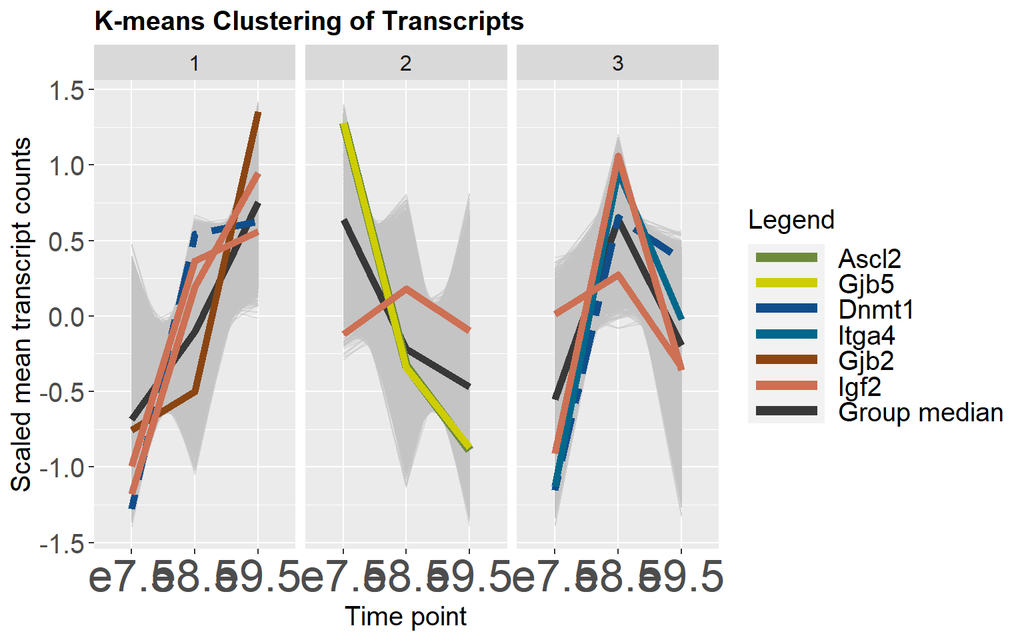

```r
set.seed(123)
tpm2 <- read.table("Files/tpmForClustering.txt", row.names = 1, header = T, sep = "\t")
km <- kmeans(tpm2, centers = 3)
trans_cluster_kmeans <- km$cluster %>% enframe()
summKmeans <- summ(trans_cluster_kmeans, tpm2)
p <- plotClus(summKmeans, "K-means Clustering of Transcripts")
p
```

For self-organizing maps:

```r
library("kohonen")
set.seed(123)
som <- som(as.matrix(tpm2), grid = somgrid(3, 1, "rectangular"))
trans_cluster_som <- som$unit.classif %>% enframe()
trans_cluster_som$name <- row.names(tpm2)
```

Since this run could take time, I saved the results to reproduce the plot here.

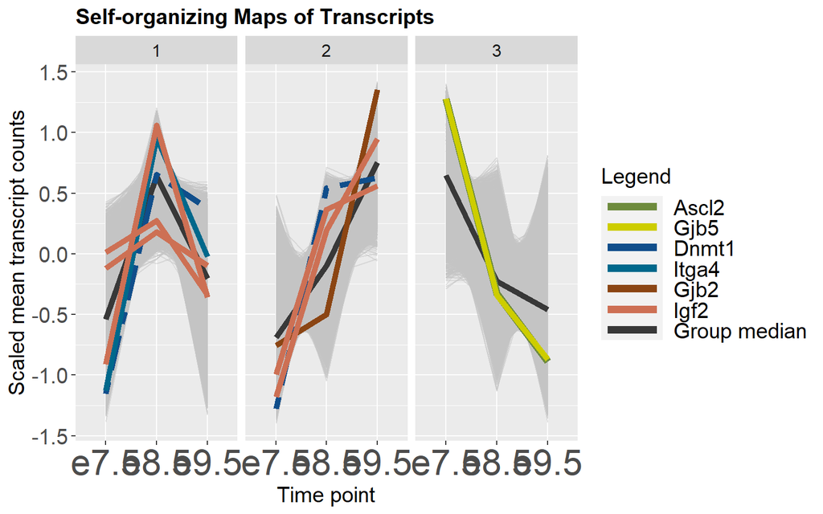

```r
trans_cluster_som <- read.table("Files/trans_cluster_som.txt", header = T)
summSOM <- summ(trans_cluster_som, tpm2)
p <- plotClus(summSOM, "Self-organizing Maps of Transcripts")
p
```

For spectral clustering:  
This clustering method required high memory and computing time, so we should run this analysis on a HPC cluster. If you are reproducing this analysis from an Iowa State cluster such as pronto, the R library `Rclustool` would require to run on an *interactive* node with X11 forwarding enabled (see https://researchit.las.iastate.edu/x-forwarding-mac-and-windows). Additionally, request high memory (for example, 128G) to run the analysis. It can take a few hours to finish running.

```r
library("RclusTool")
set.seed(123)
sim <- computeGaussianSimilarity(tpm2, 1)
res <- spectralClustering(sim, K=3)
trans_cluster_sc <- data_frame(row.names(tpm2), res$label)
colnames(trans_cluster_sc) <- c("name", "value")
```

Plot of transcripts:

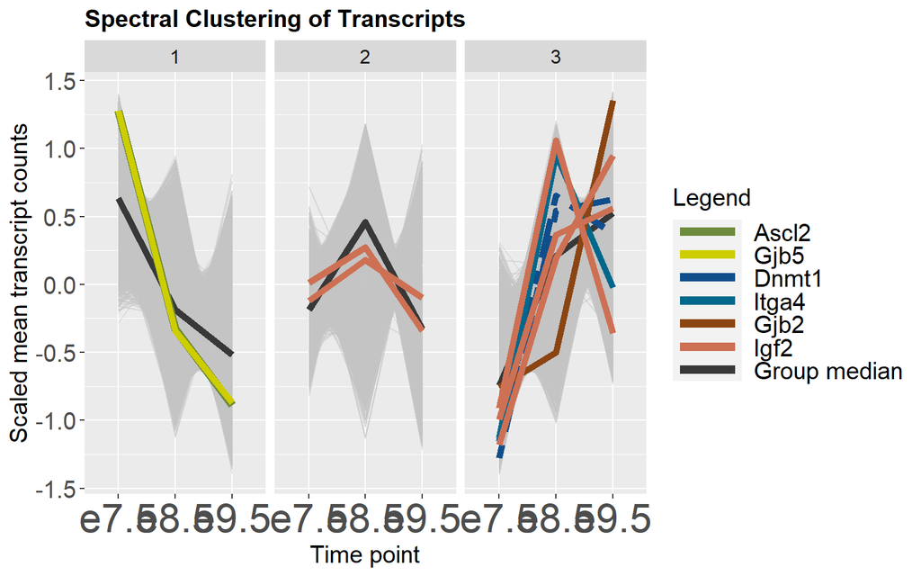

```r
trans_cluster_sc <- read.table("Files/trans_cluster_sc.txt", header = T)
summSC <- summ(trans_cluster_sc, tpm2)
p <- plotClus(summSC, "Spectral Clustering of Transcripts")
p
```

We can see the cluster trends agree with these of hierarchical clustering.

## 2. Marker counts in hierarchical groups

Markers were collected from 5 review papers (see References).  
We first load necessary files:

```r
t2g <- read.table("Files/t2g.txt", header = T, sep = "\t")

e7.5specific <- read.table("Files/e7.5specific_ensGenes.txt", header = F)
e7.5hier <- read.table("Files/e7.5Group.txt", header = T)
e8.5specific <- read.table("Files/e8.5specific_ensGenes.txt", header = F)
e8.5hier <- read.table("Files/e8.5Group.txt", header = T)
e9.5specific <- read.table("Files/e9.5specific_ensGenes.txt", header = F)
e9.5hier <- read.table("Files/e9.5Group.txt", header = T)
```

Trophoblast giant cell differentiation markers:

```r
tgc <- read.table("Files/0_e7.5_TGCdiffMarkers.txt", header = F)
tgc <- dplyr::inner_join(tgc, t2g[,2:3], by = c("V1" = "ext_gene"))
tgc <- dplyr::distinct(tgc)

tgc[tgc$ens_gene %in% e7.5specific$V1,]
```

```
#>       V1           ens_gene
#> 1  Hand1 ENSMUSG00000037335
#> 3  Ascl2 ENSMUSG00000009248
#> 8  Gata3 ENSMUSG00000015619
#> 17 Pthlh ENSMUSG00000048776
#> 25  Gmnn ENSMUSG00000006715
```

```r
tgc[tgc$ens_gene %in% e7.5hier$ens_gene,]
```

```
#>        V1           ens_gene
#> 1   Hand1 ENSMUSG00000037335
#> 2    Mdfi ENSMUSG00000032717
#> 3   Ascl2 ENSMUSG00000009248
#> 5     Eed ENSMUSG00000030619
#> 6   Snai1 ENSMUSG00000042821
#> 7   Gata2 ENSMUSG00000015053
#> 8   Gata3 ENSMUSG00000015619
#> 9   Sox15 ENSMUSG00000041287
#> 10    Lif ENSMUSG00000034394
#> 11   Lifr ENSMUSG00000054263
#> 12  Socs3 ENSMUSG00000053113
#> 13   Jak1 ENSMUSG00000028530
#> 16   Rxrb ENSMUSG00000039656
#> 17  Pthlh ENSMUSG00000048776
#> 18  Fbxw7 ENSMUSG00000028086
#> 21  Ccne2 ENSMUSG00000028212
#> 22 Cdkn1c ENSMUSG00000037664
#> 23  Trp53 ENSMUSG00000059552
#> 25   Gmnn ENSMUSG00000006715
```

```r
tgc[tgc$ens_gene %in% e8.5specific$V1,]
```

```
#>    V1           ens_gene
#> 5 Eed ENSMUSG00000030619
```

```r
tgc[tgc$ens_gene %in% e8.5hier$ens_gene,]
```

```
#>        V1           ens_gene
#> 2    Mdfi ENSMUSG00000032717
#> 5     Eed ENSMUSG00000030619
#> 11   Lifr ENSMUSG00000054263
#> 15   Rxra ENSMUSG00000015846
#> 18  Fbxw7 ENSMUSG00000028086
#> 19    Chm ENSMUSG00000025531
#> 20  Ccne1 ENSMUSG00000002068
#> 21  Ccne2 ENSMUSG00000028212
#> 22 Cdkn1c ENSMUSG00000037664
#> 23  Trp53 ENSMUSG00000059552
#> 25   Gmnn ENSMUSG00000006715
```

```r
dim(tgc[tgc$ens_gene %in% e8.5hier$ens_gene,])
```

```
#> [1] 11  2
```

```r
tgc[tgc$ens_gene %in% e9.5specific$V1,]
```

```
#>         V1           ens_gene
#> 4  Bhlhe40 ENSMUSG00000030103
#> 11    Lifr ENSMUSG00000054263
#> 15    Rxra ENSMUSG00000015846
#> 24    Mfn2 ENSMUSG00000029020
```

```r
tgc[tgc$ens_gene %in% e9.5hier$ens_gene,]
```

```
#>         V1           ens_gene
#> 4  Bhlhe40 ENSMUSG00000030103
#> 11    Lifr ENSMUSG00000054263
#> 14   Stat3 ENSMUSG00000004040
#> 15    Rxra ENSMUSG00000015846
#> 21   Ccne2 ENSMUSG00000028212
#> 22  Cdkn1c ENSMUSG00000037664
#> 23   Trp53 ENSMUSG00000059552
#> 24    Mfn2 ENSMUSG00000029020
#> 26   Procr ENSMUSG00000027611
```

```r
dim(tgc[tgc$ens_gene %in% e9.5hier$ens_gene,])
```

```
#> [1] 9 2
```

Ectoplacental cone and spongiotrophoblast maintainance markers:

```r
epcSpt <- read.table("Files/0_e7.5_EPC-SGT-markers.txt", header = F)
epcSpt <- dplyr::inner_join(epcSpt, t2g[,2:3], by = c("V1" = "ext_gene"))
epcSpt <- dplyr::distinct(epcSpt)

epcSpt[epcSpt$ens_gene %in% e7.5specific$V1,]
```

```
#>       V1           ens_gene
#> 1  Ascl2 ENSMUSG00000009248
#> 5  Ppard ENSMUSG00000002250
#> 16  Gjb5 ENSMUSG00000042357
#> 23  Ets2 ENSMUSG00000022895
```

```r
epcSpt[epcSpt$ens_gene %in% e7.5hier$ens_gene,]
```

```
#>        V1           ens_gene
#> 1   Ascl2 ENSMUSG00000009248
#> 2     Sp1 ENSMUSG00000001280
#> 3     Sp3 ENSMUSG00000027109
#> 5   Ppard ENSMUSG00000002250
#> 8   Hif1a ENSMUSG00000021109
#> 9  Cited1 ENSMUSG00000051159
#> 10 Cited2 ENSMUSG00000039910
#> 14  Krt19 ENSMUSG00000020911
#> 15   Gjb3 ENSMUSG00000042367
#> 16   Gjb5 ENSMUSG00000042357
#> 17  Birc6 ENSMUSG00000024073
#> 18   Hopx ENSMUSG00000059325
#> 22   Hsf1 ENSMUSG00000022556
#> 23   Ets2 ENSMUSG00000022895
```

```r
dim(epcSpt[epcSpt$ens_gene %in% e7.5hier$ens_gene,])
```

```
#> [1] 14  2
```

```r
epcSpt[epcSpt$ens_gene %in% e8.5specific$V1,]
```

```
#>        V1           ens_gene
#> 2     Sp1 ENSMUSG00000001280
#> 7    Arnt ENSMUSG00000015522
#> 11 Dnmt3l ENSMUSG00000000730
```

```r
epcSpt[epcSpt$ens_gene %in% e8.5hier$ens_gene,]
```

```
#>        V1           ens_gene
#> 2     Sp1 ENSMUSG00000001280
#> 4   Pparg ENSMUSG00000000440
#> 5   Ppard ENSMUSG00000002250
#> 7    Arnt ENSMUSG00000015522
#> 8   Hif1a ENSMUSG00000021109
#> 9  Cited1 ENSMUSG00000051159
#> 11 Dnmt3l ENSMUSG00000000730
#> 17  Birc6 ENSMUSG00000024073
#> 22   Hsf1 ENSMUSG00000022556
```

```r
dim(epcSpt[epcSpt$ens_gene %in% e8.5hier$ens_gene,])
```

```
#> [1] 9 2
```

```r
epcSpt[epcSpt$ens_gene %in% e9.5specific$V1,]
```

```
#>       V1           ens_gene
#> 4  Pparg ENSMUSG00000000440
#> 6  Epas1 ENSMUSG00000024140
#> 13 Krt18 ENSMUSG00000023043
#> 21  Egfr ENSMUSG00000020122
```

```r
epcSpt[epcSpt$ens_gene %in% e9.5hier$ens_gene,]
```

```
#>        V1           ens_gene
#> 4   Pparg ENSMUSG00000000440
#> 6   Epas1 ENSMUSG00000024140
#> 10 Cited2 ENSMUSG00000039910
#> 12   Krt8 ENSMUSG00000049382
#> 13  Krt18 ENSMUSG00000023043
#> 17  Birc6 ENSMUSG00000024073
#> 19   Tln1 ENSMUSG00000028465
#> 21   Egfr ENSMUSG00000020122
#> 22   Hsf1 ENSMUSG00000022556
```

```r
dim(epcSpt[epcSpt$ens_gene %in% e9.5hier$ens_gene,])
```

```
#> [1] 9 2
```

Chorioallantoic attachment markers:

```r
chorioAll <- read.table("Files/0_e8.5_chorioallantoicAttachment.txt", header = F)
chorioAll <- dplyr::left_join(chorioAll, t2g[,2:3], by = c("V1" = "ext_gene"))
chorioAll <- dplyr::distinct(chorioAll)

chorioAll[chorioAll$ens_gene %in% e7.5specific$V1,]
```

```
#>       V1           ens_gene
#> 21 Ctbp2 ENSMUSG00000030970
#> 23  Grb2 ENSMUSG00000059923
```

```r
chorioAll[chorioAll$ens_gene %in% e7.5hier$ens_gene,]
```

```
#>        V1           ens_gene
#> 6  Dnajb6 ENSMUSG00000029131
#> 11   Cdx2 ENSMUSG00000029646
#> 12  Plpp3 ENSMUSG00000028517
#> 13   Ccnf ENSMUSG00000072082
#> 16  Esrrb ENSMUSG00000021255
#> 17  Fgfr2 ENSMUSG00000030849
#> 21  Ctbp2 ENSMUSG00000030970
#> 22  Ctbp1 ENSMUSG00000037373
#> 23   Grb2 ENSMUSG00000059923
#> 25  Wnt7b ENSMUSG00000022382
```

```r
dim(chorioAll[chorioAll$ens_gene %in% e7.5hier$ens_gene,])
```

```
#> [1] 10  2
```

```r
chorioAll[chorioAll$ens_gene %in% e8.5specific$V1,]
```

```
#>       V1           ens_gene
#> 2   Bmp5 ENSMUSG00000032179
#> 3  Dnmt1 ENSMUSG00000004099
#> 4  Itga4 ENSMUSG00000027009
#> 15  Ubr5 ENSMUSG00000037487
#> 20  Tbx4 ENSMUSG00000000094
#> 24  Rbpj ENSMUSG00000039191
#> 25 Wnt7b ENSMUSG00000022382
```

```r
chorioAll[chorioAll$ens_gene %in% e8.5hier$ens_gene,]
```

```
#>        V1           ens_gene
#> 1    Bmp7 ENSMUSG00000008999
#> 2    Bmp5 ENSMUSG00000032179
#> 3   Dnmt1 ENSMUSG00000004099
#> 4   Itga4 ENSMUSG00000027009
#> 6  Dnajb6 ENSMUSG00000029131
#> 7    Lef1 ENSMUSG00000027985
#> 13   Ccnf ENSMUSG00000072082
#> 15   Ubr5 ENSMUSG00000037487
#> 17  Fgfr2 ENSMUSG00000030849
#> 20   Tbx4 ENSMUSG00000000094
#> 23   Grb2 ENSMUSG00000059923
#> 24   Rbpj ENSMUSG00000039191
#> 25  Wnt7b ENSMUSG00000022382
```

```r
dim(chorioAll[chorioAll$ens_gene %in% e8.5hier$ens_gene,])
```

```
#> [1] 13  2
```

```r
chorioAll[chorioAll$ens_gene %in% e9.5specific$V1,]
```

```
#>       V1           ens_gene
#> 10 Vcam1 ENSMUSG00000027962
#> 19 Smad1 ENSMUSG00000031681
#> 20  Tbx4 ENSMUSG00000000094
```

```r
chorioAll[chorioAll$ens_gene %in% e9.5hier$ens_gene,]
```

```
#>         V1           ens_gene
#> 6   Dnajb6 ENSMUSG00000029131
#> 10   Vcam1 ENSMUSG00000027962
#> 14    Ccn1 ENSMUSG00000028195
#> 17   Fgfr2 ENSMUSG00000030849
#> 19   Smad1 ENSMUSG00000031681
#> 20    Tbx4 ENSMUSG00000000094
#> 22   Ctbp1 ENSMUSG00000037373
#> 26 Zfp36l1 ENSMUSG00000021127
```

```r
dim(chorioAll[chorioAll$ens_gene %in% e9.5hier$ens_gene,])
```

```
#> [1] 8 2
```

Labyrinth branching and vascularization - Syncytiotrophoblast markers:

```r
laby <- read.table("Files/0_e9.5_branching-labyrinthMarkers.txt", header = F)
laby <- dplyr::left_join(laby, t2g[,2:3], by = c("V1" = "ext_gene"))
laby <- dplyr::distinct(laby)

laby[laby$ens_gene %in% e7.5specific$V1,]
```

```
#>        V1           ens_gene
#> 6    Grb2 ENSMUSG00000059923
#> 10   Junb ENSMUSG00000052837
#> 21   Sos1 ENSMUSG00000024241
#> 38  Ctbp2 ENSMUSG00000030970
#> 64 Ube2l3 ENSMUSG00000038965
#> 67   Dll4 ENSMUSG00000027314
#> 74 Tfap2c ENSMUSG00000028640
```

```r
head(laby[laby$ens_gene %in% e7.5hier$ens_gene,])
```

```
#>          V1           ens_gene
#> 2     Fgfr2 ENSMUSG00000030849
#> 4      Gab1 ENSMUSG00000031714
#> 6      Grb2 ENSMUSG00000059923
#> 8  Hsp90ab1 ENSMUSG00000023944
#> 9     Itgav ENSMUSG00000027087
#> 10     Junb ENSMUSG00000052837
```

```r
dim(laby[laby$ens_gene %in% e7.5hier$ens_gene,])
```

```
#> [1] 32  2
```

```r
laby[laby$ens_gene %in% e8.5specific$V1,]
```

```
#>       V1           ens_gene
#> 27 Itga4 ENSMUSG00000027009
#> 28  Arnt ENSMUSG00000015522
#> 31  Bmp5 ENSMUSG00000032179
#> 43  Ubr5 ENSMUSG00000037487
#> 44 Mapk1 ENSMUSG00000063358
#> 47  Igf2 ENSMUSG00000048583
#> 51  Ubp1 ENSMUSG00000009741
#> 58  Akt1 ENSMUSG00000001729
#> 63 Rock2 ENSMUSG00000020580
#> 70  Hey2 ENSMUSG00000019789
#> 73  Rbpj ENSMUSG00000039191
```

```r
head(laby[laby$ens_gene %in% e8.5hier$ens_gene,])
```

```
#>          V1           ens_gene
#> 2     Fgfr2 ENSMUSG00000030849
#> 4      Gab1 ENSMUSG00000031714
#> 6      Grb2 ENSMUSG00000059923
#> 8  Hsp90ab1 ENSMUSG00000023944
#> 9     Itgav ENSMUSG00000027087
#> 11     Lifr ENSMUSG00000054263
```

```r
dim(laby[laby$ens_gene %in% e8.5hier$ens_gene,])
```

```
#> [1] 37  2
```

```r
laby[laby$ens_gene %in% e9.5specific$V1,]
```

```
#>        V1           ens_gene
#> 1    Dlx3 ENSMUSG00000001510
#> 3    Fzd5 ENSMUSG00000045005
#> 5    Gcm1 ENSMUSG00000023333
#> 11   Lifr ENSMUSG00000054263
#> 15    Met ENSMUSG00000009376
#> 17  Pdgfb ENSMUSG00000000489
#> 18  Pparg ENSMUSG00000000440
#> 19   Rxra ENSMUSG00000015846
#> 23   Wnt2 ENSMUSG00000010797
#> 25 Adra2b ENSMUSG00000058620
#> 26 Adra2c ENSMUSG00000045318
#> 32   Bmp2 ENSMUSG00000027358
#> 34  Cebpa ENSMUSG00000034957
#> 35  Cebpb ENSMUSG00000056501
#> 39   Gjb2 ENSMUSG00000046352
#> 47   Igf2 ENSMUSG00000048583
#> 50  Lama5 ENSMUSG00000015647
#> 54   Muc1 ENSMUSG00000042784
#> 62    Rb1 ENSMUSG00000022105
#> 63  Rock2 ENSMUSG00000020580
#> 68   Esx1 ENSMUSG00000023443
#> 69   Hey1 ENSMUSG00000040289
#> 71 Notch1 ENSMUSG00000026923
#> 72 Notch4 ENSMUSG00000015468
#> 76   Egfr ENSMUSG00000020122
#> 79  Krt18 ENSMUSG00000023043
#> 83   Tfeb ENSMUSG00000023990
```

```r
head(laby[laby$ens_gene %in% e9.5hier$ens_gene,])
```

```
#>         V1           ens_gene
#> 1     Dlx3 ENSMUSG00000001510
#> 2    Fgfr2 ENSMUSG00000030849
#> 3     Fzd5 ENSMUSG00000045005
#> 5     Gcm1 ENSMUSG00000023333
#> 8 Hsp90ab1 ENSMUSG00000023944
#> 9    Itgav ENSMUSG00000027087
```

```r
dim(laby[laby$ens_gene %in% e9.5hier$ens_gene,])
```

```
#> [1] 42  2
```

## References

1. E. D. Watson and J. C. Cross, “Development of structures and transport functions in the mouse placenta,” Physiology, vol. 20, no. 3, pp. 180–193, 2005.
2. J. C. Cross, “How to Make a Placenta: Mechanisms of Trophoblast Cell Differentiation in Mice – A Review,” vol. 26, 2005.
3. M. Hemberger and J. C. Cross, “Genes governing placental development,” vol. 12, no. 4, pp. 162–168, 2001.
4. D. Hu and J. C. Cross, “Development and function of trophoblast giant cells in the rodent placenta,” Int. J. Dev. Biol., vol. 54, no. 2–3, pp. 341–354, 2010.
5. J. Rossant, J. C. Cross, and S. Lunenfeld, “Placental Development: Lessons from Mouse Mutants,” vol. 2, no. July, pp. 538–548, 2001.